# Part II - (Ford GoBike System Data)

## by (Kimberly Peters)

## Investigation Overview

> In this analysis, I would like to figure that when and where are most trips taken, and what kind of characteristics are in these locations and time periods. The characteristics include rider's attributes (sex, age, and user_type) and duration of trips.

## Dataset Overview

> This data set includes information about individual rides made in a bike-sharing system covering the greater San Francisco Bay area in February 2019.

## (Visualization 1)

> **What hour and day of the week that has most trips?**

> It is clear that thursday and tuesday is the best day for the riders to ride the bikes which are work days and least days is sunday and saturday which are weekends.

> Peak hours are 7-9 AM and 4-6 PM. The number of trips is very low between 00:00 to 05:00

> Since we have higher ride counts on weekdays and 2 peak hours, maybe the users are students or workers going to school or work and coming back during those peak hours.

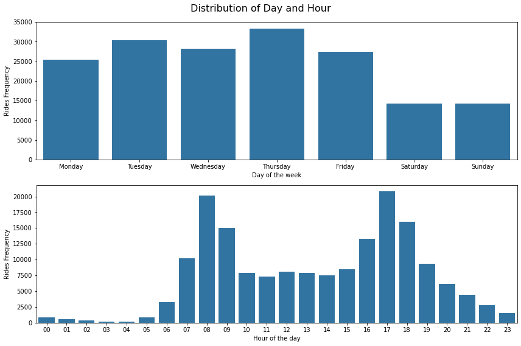

## (Visualization 2)

> **Which trip duration range has the most occurance?**

> Most of the trips have duration of less than 10 minutes

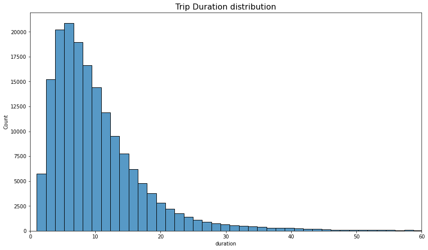

## (Visualization 3)

> **What is the distribution of user type and member genders?**

> Subcribers have done more number of rides than Customers. As subscribed member ride price is less than casual customers, this might be the reason for more number of rides. Refer [https://en.wikipedia.org/wiki/Bay_Wheels]

> Male riders counts are three times more than the Female riders. Other gender count is lesser when compared to male and female genders

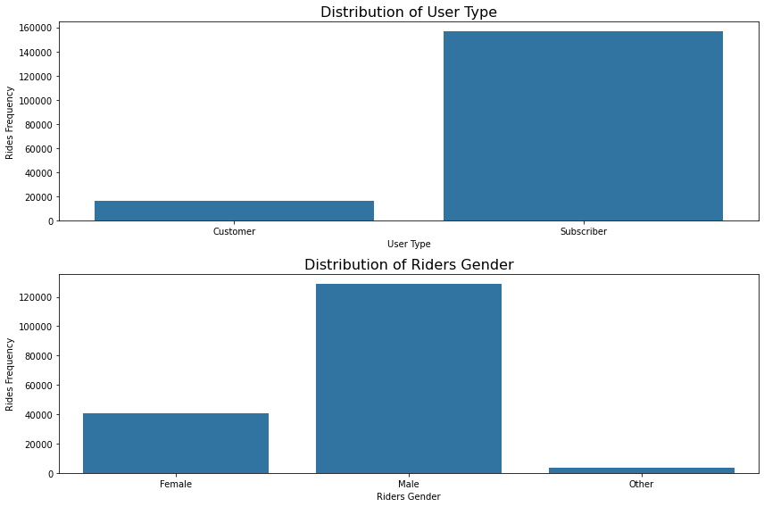

## (Visualization 4)

> **What day of the week has the most average trips duration?**

> Mean trip duration is almost the same across weekdays with a notable increase in the weekend.

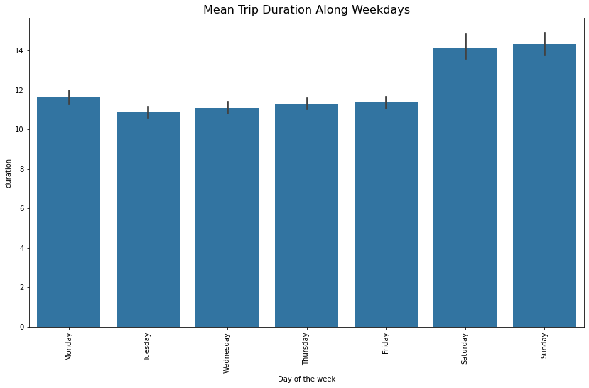

## (Visualization 5)

> **What is the mean trip duration by gender, user type and bike sharing for all trips?**

> Average trip duration is highest for "Other" gender category.

> Trip duration is slightly higher for females than males.

> Average trips duration for Customers is double that of Subscribers.

> Cyclists in the "Bike Share for All" program take slightly shorter trips than other Cyclists.

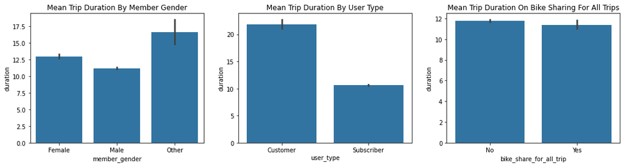

## (Visualization 6)

> **What is the relationship between Weekdays, Average duration, Bike share for all trips and the User Gender?**

> The plot shows the mean trip duration across weekdays for gender, user type, and Bike Share program.

> 'Other' gender has the most average trip duration especially on Sundays.

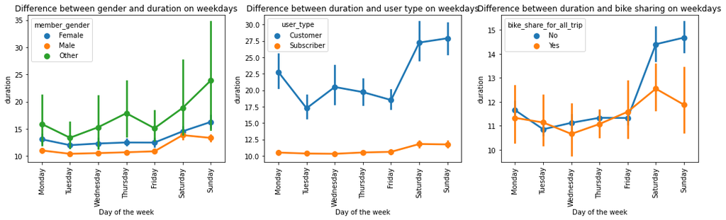